# CKD - Final

#### **2) Selecting best features for predicting Dialysis**

**Pre-requisite:** Only include AKI == 1 (determine if the patient diagnosed with AKI is receiving dialysis or not)

Based on the results below, PCA gave the highest test accuracy of 0.74 with the top 5 components. Since PCA transforms the data into principal components (which are linear combinations of the original features), it is difficult to interpret the individual features selected. Therefore, I will use the top 10 features selected by SelectKBest with Mutual Information, as listed below:

['Thomay' 'Glasgow' 'HATB' 'SOFA' 'APACHEII' 'Ure' 'Creatinin' 'PCT0' 'BiLIrubin' 'BC0']

```python
# Split the data into X (features) and y
X2 = df_encoded[df_encoded['AKI'] == 1].drop(['AKI', 'Dialysis'], # Remove y & extra column
            axis=1)  # Features
y2 = df_encoded[df_encoded['AKI'] == 1]['Dialysis']  # Target variable #2
```

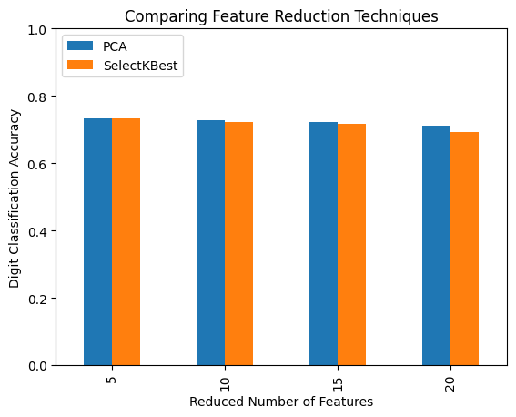

```
Best Model Parameters: {'classify__C': 1, 'reduce_dim': PCA(iterated_power=10), 'reduce_dim__n_components': 5}
Test accuracy on the full dataset: 0.7434944237918215
PCA was used for dimensionality reduction.
Explained Variance by PCA Components:
Component 1: 0.2118
Component 2: 0.1736
Component 3: 0.1405
Component 4: 0.1056
Component 5: 0.0713
+----+--------------------+--------------------+
|    |        PCA         |    SelectKBest     |
+----+--------------------+--------------------+
| 5  | 0.7328441649196368 | 0.7328441649196368 |
| 10 | 0.7292103424178896 | 0.7218029350104822 |
| 15 | 0.7217330538085255 | 0.7180293501048218 |
| 20 | 0.7106219426974144 | 0.6920335429769392 |
+----+--------------------+--------------------+
```

```python
# Define options for the number of features and C values
N_FEATURES_OPTIONS = [5, 10, 15, 20]
C_OPTIONS = [1, 10, 100, 1000]

# Call the function with the entire dataset
grid_search_results, mean_scores_df, best_model = run_grid_search(X2, y2, N_FEATURES_OPTIONS, C_OPTIONS)
```

```python
# Create the pipeline with scaling and SelectKBest
pipe = Pipeline([
    ("scaling", MinMaxScaler()),
    ("select_kbest", SelectKBest(mutual_info_classif)),  # Feature selection
    ("classify", LinearSVC(dual=False, max_iter=10000, random_state=42)),  # Classifier
])

# Define the parameter grid
N_FEATURES_OPTIONS = [5, 10, 15, 20]  # Example feature options
param_grid = {
    "select_kbest__k": N_FEATURES_OPTIONS,
    "classify__C": [0.1, 1, 10]  # Hyperparameter for LinearSVC
}

# Run GridSearchCV
grid = GridSearchCV(pipe, param_grid=param_grid, n_jobs=1)
grid.fit(X2, y2)

# Get the best model
best_model = grid.best_estimator_
print(f"Best Model Parameters: {grid.best_params_}")

# Check if SelectKBest was used and print the top selected features
if isinstance(best_model.named_steps["select_kbest"], SelectKBest):
    selector = best_model.named_steps["select_kbest"]
    selected_features_mask = selector.get_support()
    selected_features = np.array(X.columns)[selected_features_mask]
    print("Top Selected Features by SelectKBest:")
    print(selected_features)

    # Get ranking of features (lower rank means more important)
    scores = selector.scores_
    scores_df = pd.DataFrame({
        'Feature': X.columns,
        'Score': scores
    }).sort_values(by='Score', ascending=False)
    print(tabulate(scores_df, headers='keys', tablefmt='pretty'))

    # Print mean_scores in table format
    print(tabulate(mean_scores_df, headers='keys', tablefmt='pretty'))
else:
    print("The best model did not use SelectKBest for feature selection.")
```

```
Best Model Parameters: {'classify__C': 0.1, 'select_kbest__k': 10}
Top Selected Features by SelectKBest:
['Thomay' 'Glasgow' 'HATB' 'SOFA' 'APACHEII' 'Ure' 'Creatinin' 'PCT0'
 'BiLIrubin' 'BC0']
+----+-----------+------------------------+
|    |  Feature  |         Score          |
+----+-----------+------------------------+
| 5  |  Thomay   |   0.2985340757191446   |
| 9  |   HATB    |  0.25255455613143907   |
| 16 |    Ure    |  0.23906325067953227   |
| 6  |  Glasgow  |  0.19476243105204571   |
| 11 |   SOFA    |  0.09439446085326897   |
| 17 | Creatinin |  0.08928525090153272   |
| 12 | APACHEII  |  0.07479044541449098   |
| 21 |    BC0    |  0.05940762607745431   |
| 19 | BiLIrubin |  0.05544112800576895   |
| 18 |   PCT0    |  0.049663776370779456  |
| 13 |    pH     |   0.0494519129389015   |
| 20 |  Albumin  |  0.04525325504575983   |
| 1  |    Age    |  0.03681233619591917   |
| 10 |  Nhiptho  |  0.034662117696739436  |
| 3  |    THA    |  0.02831677582162917   |
| 7  |   Mach    |  0.024373498822683803  |
| 0  |  Gender   |  0.022641547640728676  |
| 14 |   HCO3    |  0.010752534093095623  |
| 2  |  Causes   |  0.004320597851895425  |
| 8  |  Nhietdo  | 0.00023682075158526494 |
| 4  |    DTD    |          0.0           |
| 15 |  Lactac0  |          0.0           |
+----+-----------+------------------------+
+----+--------------------+--------------------+
|    |        PCA         |    SelectKBest     |
+----+--------------------+--------------------+
| 5  | 0.7328441649196368 | 0.7328441649196368 |
| 10 | 0.7292103424178896 | 0.7218029350104822 |
| 15 | 0.7217330538085255 | 0.7180293501048218 |
| 20 | 0.7106219426974144 | 0.6920335429769392 |
+----+--------------------+--------------------+
```

### **Step 7: Model Building**

Checking the distributions of AKI and Dialysis, both are balanced.

```python
df_encoded['AKI'].value_counts(normalize=True)
```

```
AKI
1    0.530572
0    0.469428
Name: proportion, dtype: float64
```

```python
df_encoded.loc[df_encoded['AKI'] == 1, 'Dialysis'].value_counts(normalize=True)
```

```
Dialysis
1    0.553903
0    0.446097
Name: proportion, dtype: float64
```

#### **1) Select best model to predict AKI**

Using Random Forest on the top 15 reduced features gave the most optimal result. On the other hand, Mahalanobis classifier performed best on Recall but worst overall.

```python
from scipy.spatial import distance
from scipy.spatial.distance import cdist
from scipy.spatial.distance import mahalanobis
from sklearn.base import BaseEstimator, ClassifierMixin
from sklearn.ensemble import RandomForestClassifier
from sklearn.linear_model import LogisticRegression
from sklearn.metrics import accuracy_score, precision_score, recall_score, f1_score, roc_auc_score, average_precision_score, confusion_matrix
from sklearn.model_selection import train_test_split
from sklearn.svm import SVC
from sklearn.utils.class_weight import compute_class_weight
from xgboost import XGBClassifier
import numpy as np
import pandas as pd
import xgboost as xgb

# Function to evaluate model performance
def evaluation_metrics(model, X_test, y_test):
    y_pred = model.predict(X_test)
    # Compute the evaluation metrics
    metrics = {
        'accuracy': accuracy_score(y_test, y_pred),
        'precision': precision_score(y_test, y_pred),
        'recall': recall_score(y_test, y_pred),
        'f1': f1_score(y_test, y_pred),
        'roc_auc': roc_auc_score(y_test, y_pred),
        'auprc': average_precision_score(y_test, y_pred),
        'confusion_matrix': confusion_matrix(y_test, y_pred)
    }
    return metrics

# Function to create and evaluate different models
def evaluate_models(X_train, X_test, y_train, y_test, dataset_name):
    results = []
    class_weights=[None, 'balanced']
    model_types = ['Random Forest', 'XGBoost', 'SVM', 'Logistic Regression']

    for class_weight in class_weights:
        for model_type in model_types:
            #print(f"Training {model_type} with class_weight={class_weight}")

            # Initialize model based on type
            if model_type == 'Random Forest':
                model = RandomForestClassifier(class_weight=class_weight, random_state=42)
            elif model_type == 'XGBoost':
                #model = xgb.XGBClassifier(random_state=42)
                model = XGBClassifier(
                    scale_pos_weight=(len(y_train) - sum(y_train)) / sum(y_train),
                    random_state=42
                )  # XGBoost handles imbalance with scale_pos_weight
            elif model_type == 'SVM':
                model = SVC(probability=True, class_weight=class_weight, random_state=42)
            elif model_type == 'Logistic Regression':
                model = LogisticRegression(class_weight=class_weight, max_iter=10000, random_state=42)

            # Train model
            trained_model = model.fit(X_train, y_train)

            # Evaluate model
            metrics = evaluation_metrics(trained_model, X_test, y_test)
            results.append({
                'model': model_type,
                'dataset': dataset_name,
                'class_weight': class_weight,
                **metrics
            })

    return pd.DataFrame(results)

def evaluate_mahalanobis(X_train, X_test, y_train, y_test, dataset_name):
    # Separate the data by class
    class_0 = X_train[y_train == 0]
    class_1 = X_train[y_train == 1]

    # Calculate the mean vector and covariance matrix for each class
    mean_0 = class_0.mean(axis=0)
    mean_1 = class_1.mean(axis=0)

    cov_0 = np.cov(class_0.T) + np.eye(class_0.shape[1]) * 1e-6  # Regularization for stability
    cov_1 = np.cov(class_1.T) + np.eye(class_1.shape[1]) * 1e-6  # Regularization for stability

    # Calculate the inverse of the covariance matrices
    inv_cov_0 = np.linalg.inv(cov_0)
    inv_cov_1 = np.linalg.inv(cov_1)

    # Compute Mahalanobis distances for each class
    def mahalanobis_distance(X, mean, inv_cov):
        return np.sqrt(np.sum(np.dot(X - mean, inv_cov) * (X - mean), axis=1))

    # Classify test samples based on the Mahalanobis distance to each class
    def mahalanobis_classifier(X, mean_0, inv_cov_0, mean_1, inv_cov_1):
        dist_0 = mahalanobis_distance(X, mean_0, inv_cov_0)
        dist_1 = mahalanobis_distance(X, mean_1, inv_cov_1)
        return np.where(dist_0 < dist_1, 0, 1)

    # Predict on the test set
    y_pred = mahalanobis_classifier(X_test, mean_0, inv_cov_0, mean_1, inv_cov_1)

    # Compute Evaluation Metrics
    metrics = {
        'model': 'Mahalanobis',
        'dataset': dataset_name,
        'class_weight': 'None',
        'accuracy': accuracy_score(y_test, y_pred),
        'precision': precision_score(y_test, y_pred),
        'recall': recall_score(y_test, y_pred),
        'f1': f1_score(y_test, y_pred),
        'roc_auc': roc_auc_score(y_test, y_pred),
        'auprc': average_precision_score(y_test, y_pred),
        'confusion_matrix': confusion_matrix(y_test, y_pred)  # Store as a list to avoid issues
    }

    return pd.DataFrame([metrics])
```

```python
# Define X & y
X = df_encoded.drop(['AKI', 'Dialysis'], axis=1)
y = df_encoded['AKI']

# Split the data once and use the same split for all experiments
X_train, X_test, y_train, y_test = train_test_split(X, y, test_size=0.2, stratify=y, random_state=42)

# Run experiments separately for baseline and reduced datasets
#reduced_columns = ['Albumin', 'pH', 'Ure', 'Creatinin', 'HCO3']
#reduced_columns = ['SOFA', 'pH', 'HCO3', 'Lactac0', 'Ure', 'Creatinin', 'PCT0', 'BiLIrubin', 'Albumin', 'BC0']
reduced_columns = ['Age', 'Thomay', 'HATB', 'Nhiptho', 'SOFA', 'APACHEII', 'pH', 'HCO3', 'Lactac0', 'Ure', 'Creatinin', 'PCT0', 'BiLIrubin', 'Albumin', 'BC0']

results_baseline = evaluate_models(X_train, X_test, y_train, y_test, 'baseline')
results_reduced = evaluate_models(X_train.loc[:,reduced_columns], X_test.loc[:,reduced_columns], y_train, y_test, 'reduced')
mahalanobis_baseline = evaluate_mahalanobis(X_train, X_test, y_train, y_test, dataset_name="baseline")
mahalanobis_reduced = evaluate_mahalanobis(X_train.loc[:, reduced_columns],
                                       X_test.loc[:, reduced_columns],
                                       y_train, y_test,
                                       dataset_name="reduced")

# Merge results into one DataFrame
final_results = pd.concat([results_baseline, results_reduced, mahalanobis_baseline, mahalanobis_reduced], ignore_index=True)

# Highlight the maximum value in red per column
metric_columns = ['accuracy', 'precision', 'recall', 'f1', 'roc_auc', 'auprc']
def highlight_max(s):
    is_max = s == s.max()
    return ['color: red' if v else '' for v in is_max]

# Display the styled DataFrame
styled_results = final_results.style.apply(highlight_max, subset=metric_columns)
styled_results
```

|  | model | dataset | class_weight | accuracy | precision | recall | f1 | roc_auc | auprc | confusion_matrix |
| --- | --- | --- | --- | --- | --- | --- | --- | --- | --- | --- |
| 0 | Random Forest | baseline | None | 0.774510 | 0.762712 | 0.833333 | 0.796460 | 0.770833 | 0.723829 | [[34 14] [ 9 45]] |
| 1 | XGBoost | baseline | None | 0.774510 | 0.771930 | 0.814815 | 0.792793 | 0.771991 | 0.727019 | [[35 13] [10 44]] |
| 2 | SVM | baseline | None | 0.735294 | 0.775510 | 0.703704 | 0.737864 | 0.737269 | 0.702592 | [[37 11] [16 38]] |
| 3 | Logistic Regression | baseline | None | 0.696078 | 0.701754 | 0.740741 | 0.720721 | 0.693287 | 0.657073 | [[31 17] [14 40]] |
| 4 | Random Forest | baseline | balanced | 0.784314 | 0.775862 | 0.833333 | 0.803571 | 0.781250 | 0.734787 | [[35 13] [ 9 45]] |
| 5 | XGBoost | baseline | balanced | 0.774510 | 0.771930 | 0.814815 | 0.792793 | 0.771991 | 0.727019 | [[35 13] [10 44]] |
| 6 | SVM | baseline | balanced | 0.725490 | 0.782609 | 0.666667 | 0.720000 | 0.729167 | 0.698210 | [[38 10] [18 36]] |
| 7 | Logistic Regression | baseline | balanced | 0.705882 | 0.722222 | 0.722222 | 0.722222 | 0.704861 | 0.668664 | [[33 15] [15 39]] |
| 8 | Random Forest | reduced | None | 0.803922 | 0.793103 | 0.851852 | 0.821429 | 0.800926 | 0.754038 | [[36 12] [ 8 46]] |
| 9 | XGBoost | reduced | None | 0.764706 | 0.750000 | 0.833333 | 0.789474 | 0.760417 | 0.713235 | [[33 15] [ 9 45]] |
| 10 | SVM | reduced | None | 0.745098 | 0.759259 | 0.759259 | 0.759259 | 0.744213 | 0.703926 | [[35 13] [13 41]] |
| 11 | Logistic Regression | reduced | None | 0.696078 | 0.709091 | 0.722222 | 0.715596 | 0.694444 | 0.659180 | [[32 16] [15 39]] |
| 12 | Random Forest | reduced | balanced | 0.803922 | 0.783333 | 0.870370 | 0.824561 | 0.799769 | 0.750418 | [[35 13] [ 7 47]] |
| 13 | XGBoost | reduced | balanced | 0.764706 | 0.750000 | 0.833333 | 0.789474 | 0.760417 | 0.713235 | [[33 15] [ 9 45]] |
| 14 | SVM | reduced | balanced | 0.705882 | 0.760870 | 0.648148 | 0.700000 | 0.709491 | 0.679431 | [[37 11] [19 35]] |
| 15 | Logistic Regression | reduced | balanced | 0.705882 | 0.722222 | 0.722222 | 0.722222 | 0.704861 | 0.668664 | [[33 15] [15 39]] |
| 16 | Mahalanobis | baseline | None | 0.637255 | 0.607595 | 0.888889 | 0.721805 | 0.621528 | 0.598908 | [[17 31] [ 6 48]] |
| 17 | Mahalanobis | reduced | None | 0.656863 | 0.617284 | 0.925926 | 0.740741 | 0.640046 | 0.610775 | [[17 31] [ 4 50]] |

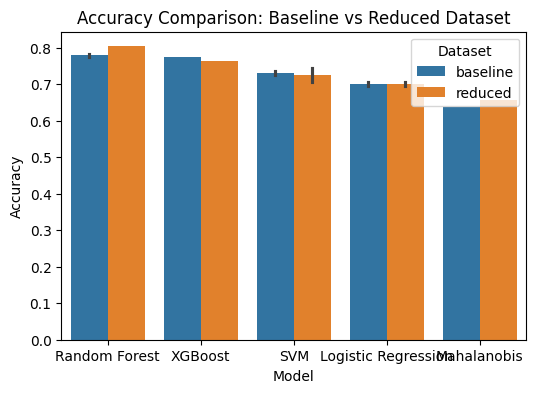

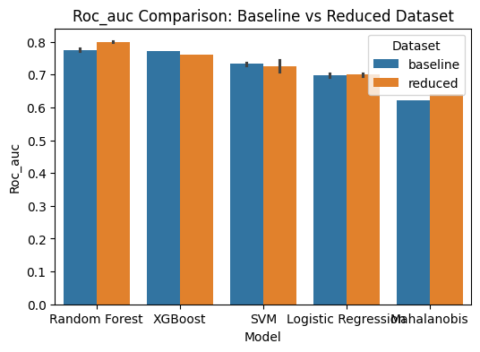

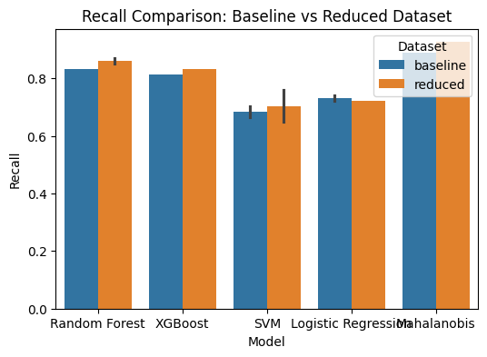

```python
# Plot accuracy comparison for each model across both datasets
metrics_to_plot = ['accuracy', 'roc_auc', 'recall']

# Loop through each metric and generate a bar plot
for metric in metrics_to_plot:
    plt.figure(figsize=(6, 4))
    sns.barplot(data=final_results, x='model', y=metric, hue='dataset')
    plt.title(f'{metric.capitalize()} Comparison: Baseline vs Reduced Dataset')
    plt.ylabel(metric.capitalize())
    plt.xlabel('Model')
    plt.legend(title='Dataset')
    plt.show()
```

#### **2) Select best model to predict Dialysis**

Using XGBoost on the baseline features yielded the best performance, but this is likely due to overfitting. Alternatively, we could explore using XGBoost or Random Forest with 10 reduced features, which also provided competitive results in terms of ROC AUC and Recall.

```python
# Do the same for Dialysis

# Define X & y
X2 = df_encoded.drop(['AKI', 'Dialysis'], axis=1)
y2 = df_encoded['Dialysis']

# Split the data once and use the same split for all experiments
X_train2, X_test2, y_train2, y_test2 = train_test_split(X2, y2, test_size=0.2, stratify=y, random_state=42)

# Run experiments separately for baseline and reduced datasets
#reduced_columns = ['HATB', 'Thomay', 'Ure', 'Glasgow', 'APACHEII', 'Creatinin', 'SOFA', 'Albumin', 'BC0', 'pH', 'Mach',
#                   'THA', 'BiLIrubin', 'Gender', 'Causes']
#reduced_columns = ['HATB', 'Thomay', 'Ure', 'Glasgow', 'SOFA']
reduced_columns = ['Thomay', 'Glasgow', 'HATB', 'SOFA', 'APACHEII', 'Ure', 'Creatinin', 'PCT0', 'BiLIrubin', 'BC0']
#reduced_columns = ['THA', 'Thomay', 'Glasgow', 'Mach', 'HATB', 'Nhiptho', 'SOFA', 'APACHEII', 'pH', 'Ure', 'Creatinin', 'PCT0', 'BiLIrubin', 'Albumin', 'BC0']

results_baseline = evaluate_models(X_train2, X_test2, y_train2, y_test2, 'baseline')
results_reduced = evaluate_models(X_train2.loc[:,reduced_columns], X_test2.loc[:,reduced_columns], y_train2, y_test2, 'reduced')
mahalanobis_baseline = evaluate_mahalanobis(X_train2, X_test2, y_train2, y_test2, dataset_name="baseline")
mahalanobis_reduced = evaluate_mahalanobis(X_train2.loc[:, reduced_columns],
                                       X_test2.loc[:, reduced_columns],
                                       y_train2, y_test2,
                                       dataset_name="reduced")

# Merge results into one DataFrame
final_results = pd.concat([results_baseline, results_reduced, mahalanobis_baseline, mahalanobis_reduced], ignore_index=True)

# Highlight the maximum value in red per column
metric_columns = ['accuracy', 'precision', 'recall', 'f1', 'roc_auc', 'auprc']
def highlight_max(s):
    is_max = s == s.max()
    return ['color: red' if v else '' for v in is_max]

# Display the styled DataFrame
styled_results = final_results.style.apply(highlight_max, subset=metric_columns)
styled_results
```

|  | model | dataset | class_weight | accuracy | precision | recall | f1 | roc_auc | auprc | confusion_matrix |
| --- | --- | --- | --- | --- | --- | --- | --- | --- | --- | --- |
| 0 | Random Forest | baseline | None | 0.843137 | 0.730769 | 0.678571 | 0.703704 | 0.791988 | 0.584114 | [[67 7] [ 9 19]] |
| 1 | XGBoost | baseline | None | 0.872549 | 0.741935 | 0.821429 | 0.779661 | 0.856660 | 0.658467 | [[66 8] [ 5 23]] |
| 2 | SVM | baseline | None | 0.764706 | 0.600000 | 0.428571 | 0.500000 | 0.660232 | 0.414006 | [[66 8] [16 12]] |
| 3 | Logistic Regression | baseline | None | 0.784314 | 0.600000 | 0.642857 | 0.620690 | 0.740347 | 0.483754 | [[62 12] [10 18]] |
| 4 | Random Forest | baseline | balanced | 0.862745 | 0.791667 | 0.678571 | 0.730769 | 0.805502 | 0.625438 | [[69 5] [ 9 19]] |
| 5 | XGBoost | baseline | balanced | 0.872549 | 0.741935 | 0.821429 | 0.779661 | 0.856660 | 0.658467 | [[66 8] [ 5 23]] |
| 6 | SVM | baseline | balanced | 0.745098 | 0.525000 | 0.750000 | 0.617647 | 0.746622 | 0.462377 | [[55 19] [ 7 21]] |
| 7 | Logistic Regression | baseline | balanced | 0.774510 | 0.558140 | 0.857143 | 0.676056 | 0.800193 | 0.517621 | [[55 19] [ 4 24]] |
| 8 | Random Forest | reduced | None | 0.852941 | 0.709677 | 0.785714 | 0.745763 | 0.832046 | 0.616427 | [[65 9] [ 6 22]] |
| 9 | XGBoost | reduced | None | 0.823529 | 0.638889 | 0.821429 | 0.718750 | 0.822876 | 0.573821 | [[61 13] [ 5 23]] |
| 10 | SVM | reduced | None | 0.764706 | 0.590909 | 0.464286 | 0.520000 | 0.671332 | 0.421409 | [[65 9] [15 13]] |
| 11 | Logistic Regression | reduced | None | 0.784314 | 0.600000 | 0.642857 | 0.620690 | 0.740347 | 0.483754 | [[62 12] [10 18]] |
| 12 | Random Forest | reduced | balanced | 0.862745 | 0.750000 | 0.750000 | 0.750000 | 0.827703 | 0.631127 | [[67 7] [ 7 21]] |
| 13 | XGBoost | reduced | balanced | 0.823529 | 0.638889 | 0.821429 | 0.718750 | 0.822876 | 0.573821 | [[61 13] [ 5 23]] |
| 14 | SVM | reduced | balanced | 0.705882 | 0.473684 | 0.642857 | 0.545455 | 0.686293 | 0.402550 | [[54 20] [10 18]] |
| 15 | Logistic Regression | reduced | balanced | 0.715686 | 0.488889 | 0.785714 | 0.602740 | 0.737452 | 0.442951 | [[51 23] [ 6 22]] |
| 16 | Mahalanobis | baseline | None | 0.696078 | 0.471698 | 0.892857 | 0.617284 | 0.757239 | 0.450571 | [[46 28] [ 3 25]] |
| 17 | Mahalanobis | reduced | None | 0.666667 | 0.448276 | 0.928571 | 0.604651 | 0.748069 | 0.435864 | [[42 32] [ 2 26]] |

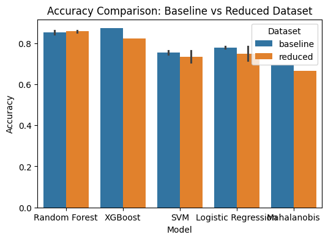

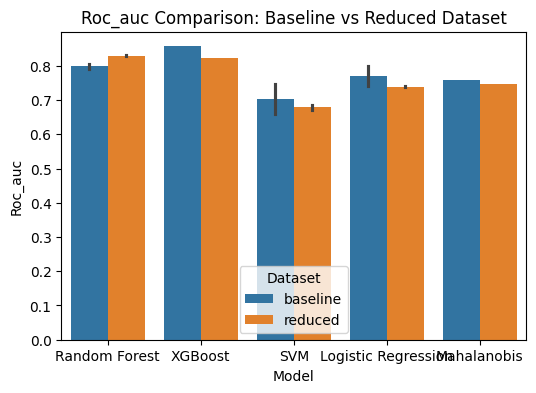

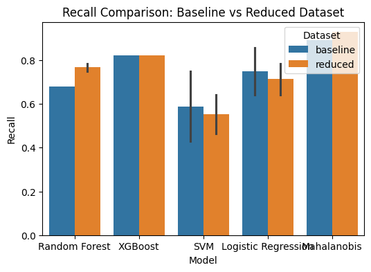

```python
# Plot accuracy comparison for each model across both datasets
metrics_to_plot = ['accuracy', 'roc_auc', 'recall']

# Loop through each metric and generate a bar plot
for metric in metrics_to_plot:
    plt.figure(figsize=(6, 4))
    sns.barplot(data=final_results, x='model', y=metric, hue='dataset')
    plt.title(f'{metric.capitalize()} Comparison: Baseline vs Reduced Dataset')
    plt.ylabel(metric.capitalize())
    plt.xlabel('Model')
    plt.legend(title='Dataset')
    plt.show()
```

### **Step 8: Model Optimization**

##### **Model Tuning and Feature Selection Process**

**Step 1: Data Preprocessing Pipeline**

- Create a data preprocessing pipeline:
  - Handle missing values (using imputation methods such as LGBMImputer).
  - Apply feature scaling (StandardScaler for numerical features).
  - Perform any necessary feature encoding (OneHotEncoder for categorical variables).
  - Implement outlier removal and other transformations (Mahalanobis distance).
  - Ensure that the preprocessing steps are encapsulated in a pipeline to ensure consistency during model training and evaluation.

**Step 2: Evaluate Feature Sets using Cross-Validation**

- Test multiple feature sets: Use the feature sets derived from the feature selection and extraction techniques (PCA & Univariate Selection using Mutual Information):
  - Baseline: Use all features (the complete set of original features).
  - Top 5: Use the top 5 features selected via PCA or univariate feature selection.
  - Top 10: Use the top 10 features selected via PCA or univariate feature selection.
  - Top 15: Use the top 15 features selected via PCA or univariate feature selection.
- Evaluate using Cross-Validation:
  - Run StratifiedKFold cross-validation for each of these feature sets and evaluate using both ROC AUC and Recall as scoring metrics. This will help assess model performance while avoiding overfitting.
  - Record and compare the cross-validation scores (ROC AUC and Recall) for each feature set to determine which feature set gives the best performance.

**Step 3: Fine-Tune with GridSearchCV**

- Use the best-performing feature set: Based on Step 2, select the feature set with the highest Recall or ROC AUC score.
- Hyperparameter tuning with GridSearchCV:
  - Feed the selected feature set into GridSearchCV to optimize hyperparameters for the model.
  - Explore different hyperparameter values (for Random Forest: n_estimators, max_depth, min_samples_split, etc.) to find the optimal configuration.
  - Ensure the GridSearchCV uses stratified k-fold cross-validation to maintain a balanced distribution of classes across the folds.
- Adjust feature sets if necessary: If the selected feature set from Step 2 doesn’t give the best performance in GridSearchCV, experiment with different combinations of features. Feature importance may provide insights into which features are most influential.

**Step 4: Select the Best Model**

- Choose the best model:
  - After running GridSearchCV, evaluate the best-performing model based on both Recall and ROC AUC scores.
  - Select the model with the highest Recall and/or the highest ROC AUC score.

**Step 5: Feature Importance and Model Interpretability**

- Examine Feature Importance:
  - Check feature importances using methods like RandomForestClassifier.feature_importances_ to understand which features are driving the model's predictions.
  - Visualize the feature importances using a bar plot for easier interpretation.
- Use SHAP for interpretability:
  - Apply SHAP (SHapley Additive exPlanations) to gain deeper insights into the model’s decision-making process.
  - Visualize SHAP values to understand the impact of each feature on the model’s predictions.
  - SHAP will help identify features that have the most positive or negative influence on the model’s output, aiding in model debugging and providing explainability.

Create pipeline.

```python
import pandas as pd
import numpy as np
from sklearn.pipeline import Pipeline
from sklearn.ensemble import RandomForestClassifier  # Updated import
from sklearn.model_selection import train_test_split
from sklearn.preprocessing import StandardScaler, OneHotEncoder
from sklearn.compose import ColumnTransformer
from sklearn.base import BaseEstimator, TransformerMixin
from sklearn.impute import SimpleImputer
from scipy.spatial.distance import mahalanobis
from sklearn.metrics import accuracy_score, classification_report, precision_score, recall_score, f1_score, roc_auc_score, average_precision_score, confusion_matrix
from lightgbm import LGBMRegressor
import warnings
from sklearn.model_selection import StratifiedKFold, cross_val_score, cross_validate

# Dummy DataFrame (Replace with your real data)
df = pd.read_excel("Original_1.xls")

# Step 1: Rename columns
df = df.rename(columns={'Chieucao': 'Height', 'Cannang': 'Weight', 'Duongvao': 'Causes',
                        'Kết cục tổn thương thận cấp': 'AKI', 'Điều trị lọc máu': 'Dialysis'})

# Step 2: Drop insignificant columns (like ID and extra columns)
df = df.drop(['STT', 'Unnamed: 25'], axis=1)

# Step 3: Delete row with invalid SOFA > 24
df = df[~((df['SOFA'] < 0) | (df['SOFA'] > 24))]

# Step 4: Drop duplicates
df = df.drop_duplicates()

# Step 5: Drop Columns with >50% Missing Data
df = df.drop(['Height', 'Weight'], axis=1)

# Step 6: Remove rows with more than 30% missing
threshold = 0.3 * df.shape[1]
df = df[df.isna().sum(axis=1) <= threshold]

# Step 7: Convert columns to categorical
df['THA'] = df['THA'].fillna(0).astype('category')
df['Gender'] = df['Gender'].astype('category')
df['Causes'] = df['Causes'].astype('category')
df['DTD'] = df['DTD'].astype('category')
df['AKI'] = df['AKI'].astype('category')
df['Dialysis'] = df['Dialysis'].astype('category')

# Step 9: Define the mapping for reorganizing 'Causes'
mapping = {
    "Hô hấp": 1,        # Respiratory system
    "Tiêu hóa": 2,      # Gastrointestinal system
    "Tiết niệu": 3,     # Urinary tract system
    "Da niêm mạc": 4,   # Skin
    "Không rõ": 5,       # Merge Unknown into Other (5)
    6: 5  # Merge Unknown into Other (5)
}
df["Causes"] = df["Causes"].replace(mapping)

# Step 10: Remove outliers
num_cols = df.select_dtypes(include=[np.number]).columns
df_num = df[num_cols]
mean_vector = df_num.mean().values
cov_matrix = df_num.cov().values
inv_cov_matrix = np.linalg.pinv(cov_matrix)
df['Mahalanobis_Distance'] = df_num.apply(lambda row: mahalanobis(row, mean_vector, inv_cov_matrix), axis=1)
df = df[(df['Mahalanobis_Distance'] <= 7) | df['Mahalanobis_Distance'].isna()]
df = df.drop(['Mahalanobis_Distance'], axis=1)

# Custom Transformer: Impute missing numerical values using LGBMRegressor
class LGBMImputer(BaseEstimator, TransformerMixin):
    def fit(self, X, y=None):
        self.models = {}
        self.missing_cols = X.columns[X.isnull().any()]
        for col in self.missing_cols:
            train_data = X[X[col].notnull()]
            X_train = train_data.drop(columns=[col])
            y_train = train_data[col]
            model = LGBMRegressor(force_col_wise=True, n_estimators=500, max_depth=10, verbosity=-1)
            model.fit(X_train, y_train)
            self.models[col] = model
        return self

    def transform(self, X):
        X = X.copy()
        for col in self.missing_cols:
            missing_mask = X[col].isnull()
            if missing_mask.sum() > 0:  # If there are missing values to impute
                X_missing = X.loc[missing_mask].drop(columns=[col])
                predictions = self.models[col].predict(X_missing)
                X.loc[missing_mask, col] = predictions
        return X

class ConvertFloatsToInt(BaseEstimator, TransformerMixin):
    def fit(self, X, y=None):
        return self  # No fitting required, just transform

    def transform(self, X):
        X = X.copy()  # Avoid changing the original data
        for col in X.columns:
            if X[col].dtype == 'float':  # Check if the column is of type float
                # Convert values to integer if the decimal part is 0 (i.e., whole numbers)
                X[col] = X[col].apply(lambda x: int(x) if x.is_integer() else x)
        return X

# Function to automatically detect numerical and categorical columns
def detect_columns(X):
    numerical_cols = X.select_dtypes(include=['number']).columns.tolist()  # All numerical columns (int, float)
    categorical_cols = X.select_dtypes(include=['category', 'object']).columns.tolist()  # All categorical columns
    return numerical_cols, categorical_cols

# Function for performing cross-validation
def run_cross_validation(X, y, skf, pipeline, dataset_name="Dataset"):
    print(f"Running cross-validation for {dataset_name}...")

    # Define the scoring metrics (ROC AUC and Recall)
    scoring = ['roc_auc', 'recall']

    # Perform cross-validation and return both ROC AUC and Recall scores
    cv_results = cross_validate(pipeline, X, y, cv=skf, scoring=scoring)

    # Print the results
    print(f"Cross-Validation ROC AUC Scores for {dataset_name}: {cv_results['test_roc_auc']}")
    print(f"Mean Cross-Validation ROC AUC for {dataset_name}: {cv_results['test_roc_auc'].mean():.4f}")
    print(f"Standard Deviation of Cross-Validation ROC AUC for {dataset_name}: {cv_results['test_roc_auc'].std():.4f}")

    print(f"Cross-Validation Recall Scores for {dataset_name}: {cv_results['test_recall']}")
    print(f"Mean Cross-Validation Recall for {dataset_name}: {cv_results['test_recall'].mean():.4f}")
    print(f"Standard Deviation of Cross-Validation Recall for {dataset_name}: {cv_results['test_recall'].std():.4f}")

    print()  # Line break

# Function to update the ColumnTransformer inside the pipeline
def update_column_transformer(X, pipeline):
    numerical_cols, categorical_cols = detect_columns(X)

    # Update the preprocessor step in the pipeline with correct columns
    pipeline.named_steps['preprocessor'].transformers[0] = ('num', num_pipeline, numerical_cols)
    pipeline.named_steps['preprocessor'].transformers[1] = ('cat', cat_pipeline, categorical_cols)

# Preprocessing pipeline for numerical data
num_pipeline = Pipeline([
    ('imputer', LGBMImputer()),  # Impute missing values using LGBMRegressor
    ('convert_to_int', ConvertFloatsToInt()),  # Convert floats with no decimal part to int
    ('scaler', StandardScaler())  # Scale numerical data
])

# Preprocessing pipeline for categorical data
cat_pipeline = Pipeline([
    ('encoder', OneHotEncoder(handle_unknown='ignore', sparse_output=False))  # One-hot encoding
])

# Column transformer to apply different pipelines to numerical and categorical columns
preprocessor = ColumnTransformer([
    ('num', num_pipeline, []),  # Placeholder for numerical columns
    ('cat', cat_pipeline, [])   # Placeholder for categorical columns
])

# Define the full_pipeline with placeholders for numerical and categorical columns
full_pipeline = Pipeline([
    ('preprocessor', ColumnTransformer([
        ('num', num_pipeline, []),  # Placeholder for numerical columns
        ('cat', cat_pipeline, [])   # Placeholder for categorical columns
    ])),
    ('classifier', RandomForestClassifier(class_weight='balanced', random_state=42))  # Classifier step
])

# Function to automatically detect numerical and categorical columns
def detect_columns(X):
    numerical_cols = X.select_dtypes(include=['number']).columns.tolist()  # All numerical columns (int, float)
    categorical_cols = X.select_dtypes(include=['category', 'object']).columns.tolist()  # All categorical columns
    return numerical_cols, categorical_cols

# Function for performing cross-validation
def run_cross_validation(X, y, skf, pipeline, dataset_name="Dataset"):
    print(f"Running cross-validation for {dataset_name}...")

    # Define the scoring metrics (ROC AUC and Recall)
    scoring = ['roc_auc', 'recall']

    # Perform cross-validation and return both ROC AUC and Recall scores
    cv_results = cross_validate(pipeline, X, y, cv=skf, scoring=scoring)

    # Print the results
    print(f"Cross-Validation ROC AUC Scores for {dataset_name}: {cv_results['test_roc_auc']}")
    print(f"Mean Cross-Validation ROC AUC for {dataset_name}: {cv_results['test_roc_auc'].mean():.4f}")
    print(f"Standard Deviation of Cross-Validation ROC AUC for {dataset_name}: {cv_results['test_roc_auc'].std():.4f}")

    print(f"Cross-Validation Recall Scores for {dataset_name}: {cv_results['test_recall']}")
    print(f"Mean Cross-Validation Recall for {dataset_name}: {cv_results['test_recall'].mean():.4f}")
    print(f"Standard Deviation of Cross-Validation Recall for {dataset_name}: {cv_results['test_recall'].std():.4f}")

    print()  # Line break
```

```python
full_pipeline
```

[output not shown]

#### **1) Optimize model to predict AKI**

**Results**:

```python
# Define X (datasets)
X1 = df_encoded.drop(['AKI', 'Dialysis'], axis=1)  # Features for baseline
X2 = df_encoded[['Albumin', 'pH', 'Ure', 'Creatinin', 'HCO3']]  # Features for top 5
X3 = df_encoded[['SOFA', 'pH', 'HCO3', 'Lactac0', 'Ure', 'Creatinin', 'PCT0', 'BiLIrubin', 'Albumin', 'BC0']]  # Features for top 10
X4 = df_encoded[['Age', 'Thomay', 'HATB', 'Nhiptho', 'SOFA', 'APACHEII', 'pH', 'HCO3', 'Lactac0', 'Ure', 'Creatinin', 'PCT0', 'BiLIrubin', 'Albumin', 'BC0']] # Features for top 15
y = df_encoded['AKI']  # Target variable

# Define StratifiedKFold
skf = StratifiedKFold(n_splits=5, shuffle=True, random_state=42)

# Run cross-validation for each dataset
for dataset, name in zip([X1, X2, X3, X4], ['X1', 'X2', 'X3', 'X4']):
    # Detect columns for preprocessing
    numerical_cols, categorical_cols = detect_columns(dataset)

    # Update the ColumnTransformer with the detected columns
    full_pipeline.named_steps['preprocessor'].transformers[0] = ('num', num_pipeline, numerical_cols)
    full_pipeline.named_steps['preprocessor'].transformers[1] = ('cat', cat_pipeline, categorical_cols)

    # Run cross-validation with the current dataset
    run_cross_validation(dataset, y, skf, full_pipeline, dataset_name=name)
```

```
Running cross-validation for X1...
Cross-Validation ROC AUC Scores for X1: [0.80632716 0.7962963  0.85579196 0.81461781 0.9634434 ]
Mean Cross-Validation ROC AUC for X1: 0.8473
Standard Deviation of Cross-Validation ROC AUC for X1: 0.0615
Cross-Validation Recall Scores for X1: [0.77777778 0.74074074 0.75925926 0.75925926 0.8490566 ]
Mean Cross-Validation Recall for X1: 0.7772
Standard Deviation of Cross-Validation Recall for X1: 0.0378

Running cross-validation for X2...
Cross-Validation ROC AUC Scores for X2: [0.77102623 0.79533179 0.80732861 0.75650118 0.92079403]
Mean Cross-Validation ROC AUC for X2: 0.8102
Standard Deviation of Cross-Validation ROC AUC for X2: 0.0581
Cross-Validation Recall Scores for X2: [0.7962963  0.74074074 0.75925926 0.7037037  0.75471698]
Mean Cross-Validation Recall for X2: 0.7509
Standard Deviation of Cross-Validation Recall for X2: 0.0299

Running cross-validation for X3...
Cross-Validation ROC AUC Scores for X3: [0.75945216 0.78915895 0.80831363 0.7677305  0.91273585]
Mean Cross-Validation ROC AUC for X3: 0.8075
Standard Deviation of Cross-Validation ROC AUC for X3: 0.0553
Cross-Validation Recall Scores for X3: [0.77777778 0.77777778 0.75925926 0.77777778 0.73584906]
Mean Cross-Validation Recall for X3: 0.7657
Standard Deviation of Cross-Validation Recall for X3: 0.0166

Running cross-validation for X4...
Cross-Validation ROC AUC Scores for X4: [0.79918981 0.80343364 0.85539795 0.82978723 0.96619497]
Mean Cross-Validation ROC AUC for X4: 0.8508
Standard Deviation of Cross-Validation ROC AUC for X4: 0.0611
Cross-Validation Recall Scores for X4: [0.7962963  0.7962963  0.75925926 0.77777778 0.81132075]
Mean Cross-Validation Recall for X4: 0.7882
Standard Deviation of Cross-Validation Recall for X4: 0.0180
```

Using RandomizedSearchCV.

```python
from sklearn.model_selection import RandomizedSearchCV
from scipy.stats import randint

# Define the parameter distribution for RandomizedSearchCV
param_dist = {
    'classifier__n_estimators': randint(50, 100),  # Randomly sample the number of trees (between 50 and 500)
    'classifier__max_depth': [None, 10, 20],  # Try different depths for the trees
    'classifier__min_samples_split': randint(2, 20),  # Randomly sample values for minimum samples to split
    'classifier__min_samples_leaf': randint(1, 10),  # Randomly sample values for minimum samples per leaf
    'classifier__max_features': ['sqrt', 5, 10]  # Number of features to consider at each split
}

# Define the datasets
X = df_encoded[['Age', 'Thomay', 'HATB', 'Nhiptho', 'SOFA', 'APACHEII', 'pH', 'HCO3', 'Lactac0', 'Ure', 'Creatinin', 'PCT0', 'BiLIrubin', 'Albumin', 'BC0']]
y = df_encoded['AKI']  # Target variable

# Split the data into training and test sets
X_train, X_test, y_train, y_test = train_test_split(X, y, test_size=0.20, stratify=y, random_state=1)

# Set up Stratified K-Fold cross-validation
skf = StratifiedKFold(n_splits=5, shuffle=True, random_state=1)

# Perform RandomizedSearchCV with 5-fold cross-validation using ROC AUC scoring
random_search_roc = RandomizedSearchCV(estimator=full_pipeline,
                                       param_distributions=param_dist,
                                       n_iter=20,  # Number of random combinations to try (adjust based on your resources)
                                       cv=skf,  # Use 5-fold cross-validation
                                       scoring='roc_auc', # Scoring metric is ROC AUC
                                       verbose=1,  # Set verbosity to 1 to see progress
                                       random_state=1,  # Ensures reproducibility
                                       n_jobs=-1  # Use all available CPUs for computation (optional)
                                      )

# Update the ColumnTransformer with the current dataset's columns before fitting RandomizedSearchCV
update_column_transformer(X_train, full_pipeline)

# Fit the RandomizedSearchCV to your training data
random_search_roc.fit(X_train, y_train)

# Display the best parameters and the best ROC AUC score found during the randomized search
print(f"Best parameters: {random_search_roc.best_params_}")
print(f"Best ROC AUC score: {random_search_roc.best_score_}")
```

```
Fitting 5 folds for each of 20 candidates, totalling 100 fits
Best parameters: {'classifier__max_depth': None, 'classifier__max_features': 'sqrt', 'classifier__min_samples_leaf': 3, 'classifier__min_samples_split': 6, 'classifier__n_estimators': 73}
Best ROC AUC score: 0.8458996328029377
```

Using GridSearchCV.

```python
from sklearn.model_selection import GridSearchCV
from sklearn.metrics import recall_score

# Define the datasets
#X = df_encoded[['Thomay', 'pH', 'Ure', 'Creatinin', 'PCT0', 'Albumin', 'HCO3']]
X = df_encoded[['pH', 'Creatinin', 'Ure', 'Albumin', 'HCO3', 'PCT0', 'SOFA', 'Lactac0', 'BC0', 'BiLIrubin', 'Thomay', 'Mach', 'APACHEII']]
#X = df_encoded[['Thomay', 'HATB', 'Nhiptho', 'SOFA', 'APACHEII', 'pH', 'HCO3', 'Lactac0', 'Ure', 'Creatinin', 'PCT0', 'BiLIrubin', 'Albumin', 'BC0']]
y = df_encoded['AKI']  # Target variable

# Split the data into training and test sets
X_train, X_test, y_train, y_test = train_test_split(X, y, test_size=0.20, stratify=y, random_state=1)

# Set up Stratified K-Fold cross-validation
skf = StratifiedKFold(n_splits=5, shuffle=True, random_state=1)

# Define the parameter grid for GridSearchCV (Example of some parameters you might tune)
param_grid = {
    'classifier__n_estimators': [50, 100, 200],  # Number of trees in the forest
    'classifier__max_depth': [None, 10, 20],  # Max depth of the trees
    'classifier__min_samples_split': [2, 10, 20],  # Min samples to split internal nodes
    'classifier__min_samples_leaf': [1, 2, 5],  # Min samples per leaf
    'classifier__max_features': ['sqrt', 'log2', None]  # Max number of features for each split
}

# Perform GridSearchCV with 5-fold cross-validation using both ROC AUC and Recall as scoring metrics
grid_search_roc_recall = GridSearchCV(estimator=full_pipeline,
                                      param_grid=param_grid,
                                      cv=skf,  # 5-fold cross-validation
                                      scoring=['roc_auc', 'recall'],  # Multiple scoring metrics
                                      refit='recall',  # Use ROC AUC to select the best model
                                      verbose=1,  # Set verbosity to 1 to see progress
                                      n_jobs=-1)  # Use all available CPUs for computation (optional)

# Update the ColumnTransformer with the current dataset's columns before fitting GridSearchCV
update_column_transformer(X_train, full_pipeline)

# Fit the GridSearchCV to your training data
grid_search_roc_recall.fit(X_train, y_train)

# Display the best parameters and the best ROC AUC score found during the grid search
print(f"Best parameters: {grid_search_roc_recall.best_params_}")
print(f"Best Recall score (based on refit='recall'): {grid_search_roc_recall.best_score_}")
print(f"Best ROC AUC score (for reference): {grid_search_roc_recall.cv_results_['mean_test_roc_auc'][grid_search_roc_recall.best_index_]}")
print(f"Best Recall score from cross-validation (for best parameters): {grid_search_roc_recall.cv_results_['mean_test_recall'][grid_search_roc_recall.best_index_]}")
```

```
Fitting 5 folds for each of 243 candidates, totalling 1215 fits
Best parameters: {'classifier__max_depth': None, 'classifier__max_features': 'sqrt', 'classifier__min_samples_leaf': 2, 'classifier__min_samples_split': 2, 'classifier__n_estimators': 50}
Best Recall score (based on refit='recall'): 0.8
Best ROC AUC score (for reference): 0.8323133414932681
Best Recall score from cross-validation (for best parameters): 0.8
```

```
Test Accuracy: 0.7745098039215687
Test ROC AUC score: 0.7754629629629629
Test Recall score: 0.7592592592592593
Classification Report:
              precision    recall  f1-score   support

           0       0.75      0.79      0.77        48
           1       0.80      0.76      0.78        54

    accuracy                           0.77       102
   macro avg       0.77      0.78      0.77       102
weighted avg       0.78      0.77      0.77       102
```

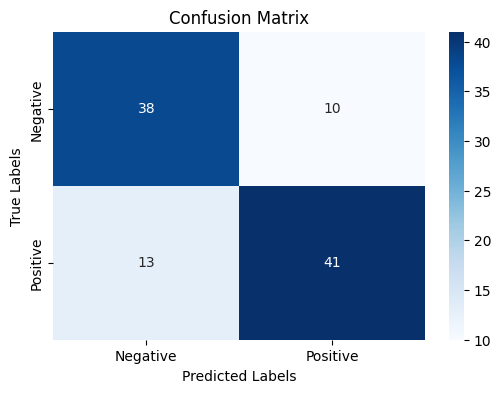

```python
from sklearn.metrics import roc_auc_score, accuracy_score, classification_report, confusion_matrix, recall_score

# Get the best estimator from the GridSearchCV
best_aki_model = grid_search_roc_recall.best_estimator_

# Make predictions on the test set
y_pred = best_aki_model.predict(X_test)

# Accuracy
accuracy = accuracy_score(y_test, y_pred)
print(f"Test Accuracy: {accuracy}")

# ROC AUC score
roc_auc = roc_auc_score(y_test, y_pred)
print(f"Test ROC AUC score: {roc_auc}")

# Recall score
recall = recall_score(y_test, y_pred)
print(f"Test Recall score: {recall}")

# Classification report
print("Classification Report:")
print(classification_report(y_test, y_pred))

# Compute the confusion matrix
cm = confusion_matrix(y_test, y_pred)

# Create a heatmap for the confusion matrix
plt.figure(figsize=(6, 4))
sns.heatmap(cm, annot=True, fmt='g', cmap='Blues', xticklabels=['Negative', 'Positive'], yticklabels=['Negative', 'Positive'])
plt.title("Confusion Matrix")
plt.xlabel("Predicted Labels")
plt.ylabel("True Labels")
plt.show()
```

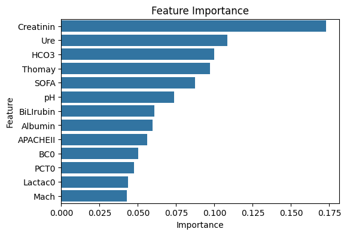

```python
# Get feature importances from the best model
importances = best_aki_model.named_steps['classifier'].feature_importances_

# Get the feature names (assuming numerical and categorical features are already combined)
# Use the column names of the dataset (after preprocessing, it would be the original columns)
feature_names = X.columns.tolist()  # Use the column names from the dataset you're working with

# Create a DataFrame for feature importances
feature_importance_df = pd.DataFrame({
    'Feature': feature_names,
    'Importance': importances
})

# Sort the features by importance
feature_importance_df = feature_importance_df.sort_values(by='Importance', ascending=False)

# Plot the feature importances using Seaborn
plt.figure(figsize=(6, 4))
sns.barplot(x='Importance', y='Feature', data=feature_importance_df)
plt.title('Feature Importance')
plt.xlabel('Importance')
plt.ylabel('Feature')
plt.show()
```

##### **Feature Importance / SHAP Interpretation (for predicting AKI):**

This aligns because:

```
Shape of shap_values_class_1: (405, 13)
Shape of X_train: (405, 13)
```

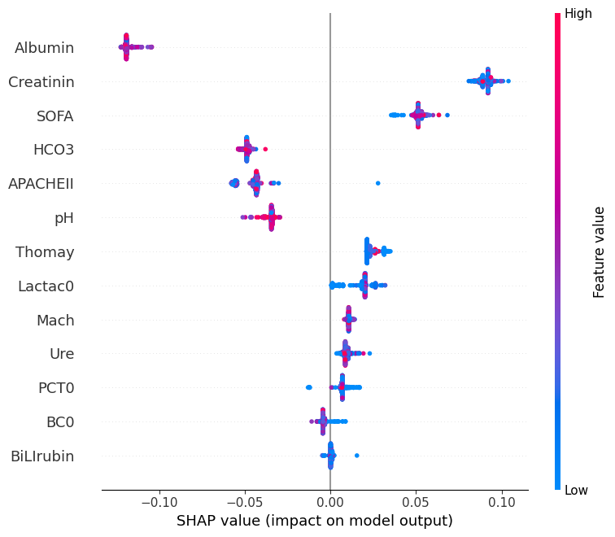

```python
import shap

# Initialize SHAP explainer
explainer = shap.TreeExplainer(best_aki_model.named_steps['classifier'])

# Get the SHAP values for both classes
shap_values = explainer.shap_values(X_train)

# Extract SHAP values for class 1 (positive class)
shap_values_class_1 = shap_values[:, :, 1]  # Select the SHAP values for class 1

# Print the shapes to check alignment
print(f"Shape of shap_values_class_1: {shap_values_class_1.shape}")
print(f"Shape of X_train: {X_train.shape}")

# Plot the SHAP summary plot for class 1 (positive class)
shap.summary_plot(shap_values_class_1, X_train)
```

#### **2) Optimize model to predict Dialysis**

**Results**:

- ML Classifier: Random Forest
- Best Feature Set: ['Thomay', 'HATB', 'Ure', 'Glasgow', 'SOFA']
- Best parameters:
  - classifier__max_depth': None,
  - 'classifier__max_features': 'sqrt',
  - 'classifier__min_samples_leaf': 2,
  - 'classifier__min_samples_split': 10,
  - 'classifier__n_estimators': 200
- Best Test Accuracy: 0.93
- Best Test ROC AUC score: 0.92
- Best Test Recall score: 0.97

```python
# Retain only AKI = 1
df2 = df_encoded.loc[df_encoded['AKI'] == 1].copy()

# Define X (datasets)
X1 = df2.drop(['AKI', 'Dialysis'], axis=1)  # Features for baseline
X2 = df2[['Thomay', 'HATB', 'Ure', 'Glasgow', 'SOFA']]  # Features for top 5
X3 = df2[['Thomay', 'Glasgow', 'HATB', 'SOFA', 'APACHEII', 'Ure', 'Creatinin', 'PCT0', 'BiLIrubin', 'BC0']]  # Features for top 10
X4 = df2[['SOFA', 'APACHEII', 'Nhiptho', 'Creatinin', 'Thomay', 'Glasgow', 'Mach', 'pH','Ure', 'THA']]
y2 = df2['Dialysis']  # Target variable

# Run cross-validation for each dataset
for dataset, name in zip([X1, X2, X3, X4], ['X1', 'X2', 'X3', 'X4']):
    # Detect columns for preprocessing
    numerical_cols, categorical_cols = detect_columns(dataset)

    # Update the ColumnTransformer with the detected columns
    full_pipeline.named_steps['preprocessor'].transformers[0] = ('num', num_pipeline, numerical_cols)
    full_pipeline.named_steps['preprocessor'].transformers[1] = ('cat', cat_pipeline, categorical_cols)

    # Run cross-validation with the current dataset
    run_cross_validation(dataset, y2, skf, full_pipeline, dataset_name=name)
```

```
Running cross-validation for X1...
Cross-Validation ROC AUC Scores for X1: [0.91666667 0.86319444 0.90138889 0.94722222 0.85057471]
Mean Cross-Validation ROC AUC for X1: 0.8958
Standard Deviation of Cross-Validation ROC AUC for X1: 0.0353
Cross-Validation Recall Scores for X1: [0.8        0.86666667 0.9        0.93333333 0.93103448]
Mean Cross-Validation Recall for X1: 0.8862
Standard Deviation of Cross-Validation Recall for X1: 0.0495

Running cross-validation for X2...
Cross-Validation ROC AUC Scores for X2: [0.95277778 0.89097222 0.90416667 0.92847222 0.90086207]
Mean Cross-Validation ROC AUC for X2: 0.9155
Standard Deviation of Cross-Validation ROC AUC for X2: 0.0224
Cross-Validation Recall Scores for X2: [0.86666667 0.9        0.9        0.9        0.86206897]
Mean Cross-Validation Recall for X2: 0.8857
Standard Deviation of Cross-Validation Recall for X2: 0.0175

Running cross-validation for X3...
Cross-Validation ROC AUC Scores for X3: [0.95       0.88819444 0.88125    0.91527778 0.86063218]
Mean Cross-Validation ROC AUC for X3: 0.8991
Standard Deviation of Cross-Validation ROC AUC for X3: 0.0309
Cross-Validation Recall Scores for X3: [0.8        0.93333333 0.9        0.93333333 0.89655172]
Mean Cross-Validation Recall for X3: 0.8926
Standard Deviation of Cross-Validation Recall for X3: 0.0489

Running cross-validation for X4...
Cross-Validation ROC AUC Scores for X4: [0.92569444 0.88888889 0.91041667 0.97222222 0.86422414]
Mean Cross-Validation ROC AUC for X4: 0.9123
Standard Deviation of Cross-Validation ROC AUC for X4: 0.0364
Cross-Validation Recall Scores for X4: [0.73333333 0.93333333 0.9        0.96666667 0.89655172]
Mean Cross-Validation Recall for X4: 0.8860
Standard Deviation of Cross-Validation Recall for X4: 0.0805
```

Using RandomizedSearchCV.

```python
# Define the parameter distribution for RandomizedSearchCV
param_dist = {
    'classifier__n_estimators': randint(50, 100),  # Randomly sample the number of trees (between 50 and 500)
    'classifier__max_depth': [None, 10, 20],  # Try different depths for the trees
    'classifier__min_samples_split': randint(2, 20),  # Randomly sample values for minimum samples to split
    'classifier__min_samples_leaf': randint(1, 10),  # Randomly sample values for minimum samples per leaf
    'classifier__max_features': ['sqrt', 5, 10]  # Number of features to consider at each split
}

# Define the datasets
# X1 = df2.drop(['AKI', 'Dialysis'], axis=1)  # Features for baseline
# X2 = df2[['Thomay', 'HATB', 'Ure', 'Glasgow', 'SOFA']]  # Features for top 5
# X3 = df2[['Thomay', 'Glasgow', 'HATB', 'SOFA', 'APACHEII', 'Ure', 'Creatinin', 'PCT0', 'BiLIrubin', 'BC0']]  # Features for top 10
# X4 = df2[['SOFA', 'APACHEII', 'Nhiptho', 'Creatinin', 'Thomay', 'Glasgow', 'Mach', 'pH','Ure', 'THA']]

X2 = df2[['SOFA', 'APACHEII', 'Nhiptho', 'Creatinin', 'Thomay', 'Glasgow', 'Mach', 'pH','Ure', 'THA']]
y2 = df2['Dialysis']  # Target variable

# Split the data into training and test sets
X_train_2, X_test_2, y_train_2, y_test_2 = train_test_split(X2, y2, test_size=0.20, stratify=y2, random_state=5)

# Set up Stratified K-Fold cross-validation
skf = StratifiedKFold(n_splits=5, shuffle=True, random_state=5)

# Perform RandomizedSearchCV with 5-fold cross-validation using ROC AUC scoring
random_search_roc_2 = RandomizedSearchCV(estimator=full_pipeline,
                                       param_distributions=param_dist,
                                       n_iter=20,  # Number of random combinations to try (adjust based on your resources)
                                       cv=skf,  # Use 5-fold cross-validation
                                       scoring=['roc_auc', 'recall'],  # Multiple scoring metrics
                                       refit='recall',  # Use ROC AUC to select the best model
                                       verbose=1,  # Set verbosity to 1 to see progress
                                       random_state=5,  # Ensures reproducibility
                                       n_jobs=-1  # Use all available CPUs for computation (optional)
                                      )

# Update the ColumnTransformer with the current dataset's columns before fitting RandomizedSearchCV
update_column_transformer(X_train_2, full_pipeline)

# Fit the RandomizedSearchCV to your training data
random_search_roc_2.fit(X_train_2, y_train_2)

# Display the best parameters and the best Recall score found during the randomized search
print(f"Best parameters: {random_search_roc_2.best_params_}")
print(f"Best Recall score (based on refit='recall'): {random_search_roc_2.best_score_}")
print(f"Best ROC AUC score (for reference): {random_search_roc_2.cv_results_['mean_test_roc_auc'][random_search_roc_2.best_index_]}")
print(f"Best Recall score from cross-validation (for best parameters): {random_search_roc_2.cv_results_['mean_test_recall'][random_search_roc_2.best_index_]}")
```

```
Fitting 5 folds for each of 20 candidates, totalling 100 fits
Best parameters: {'classifier__max_depth': 20, 'classifier__max_features': 'sqrt', 'classifier__min_samples_leaf': 1, 'classifier__min_samples_split': 10, 'classifier__n_estimators': 76}
Best Recall score (based on refit='recall'): 0.8742753623188406
Best ROC AUC score (for reference): 0.8944660564454614
Best Recall score from cross-validation (for best parameters): 0.8742753623188406
```

Using GridSearchCV.

```python
from sklearn.model_selection import GridSearchCV
from sklearn.metrics import recall_score

# Define the datasets
X2 = df2[['Thomay', 'HATB', 'Ure', 'Glasgow', 'SOFA']]
y2 = df2['Dialysis']  # Target variable

# Split the data into training and test sets
X_train_2, X_test_2, y_train_2, y_test_2 = train_test_split(X2, y2, test_size=0.20, stratify=y2, random_state=5)

# Set up Stratified K-Fold cross-validation
skf = StratifiedKFold(n_splits=5, shuffle=True, random_state=5)

# Define the parameter grid for GridSearchCV (Example of some parameters you might tune)
param_grid = {
    'classifier__n_estimators': [50, 100, 200],  # Number of trees in the forest
    'classifier__max_depth': [None, 10, 20],  # Max depth of the trees
    'classifier__min_samples_split': [2, 10, 20],  # Min samples to split internal nodes
    'classifier__min_samples_leaf': [1, 2, 5],  # Min samples per leaf
    'classifier__max_features': ['sqrt', 'log2', None]  # Max number of features for each split
}

# Perform GridSearchCV with 5-fold cross-validation using both ROC AUC and Recall as scoring metrics
grid_search_roc_recall_2 = GridSearchCV(estimator=full_pipeline,
                                      param_grid=param_grid,
                                      cv=skf,  # 5-fold cross-validation
                                      scoring=['roc_auc', 'recall'],  # Multiple scoring metrics
                                      refit='recall',  # Use ROC AUC to select the best model
                                      verbose=1,  # Set verbosity to 1 to see progress
                                      n_jobs=-1)  # Use all available CPUs for computation (optional)

# Update the ColumnTransformer with the current dataset's columns before fitting GridSearchCV
update_column_transformer(X_train_2, full_pipeline)

# Fit the GridSearchCV to your training data
grid_search_roc_recall_2.fit(X_train_2, y_train_2)

# Display the best parameters and the best ROC AUC score found during the grid search
print(f"Best parameters: {grid_search_roc_recall_2.best_params_}")
print(f"Best Recall score (based on refit='recall'): {grid_search_roc_recall_2.best_score_}")
print(f"Best ROC AUC score (for reference): {grid_search_roc_recall_2.cv_results_['mean_test_roc_auc'][grid_search_roc_recall_2.best_index_]}")
print(f"Best Recall score from cross-validation (for best parameters): {grid_search_roc_recall_2.cv_results_['mean_test_recall'][grid_search_roc_recall_2.best_index_]}")
```

```
Fitting 5 folds for each of 243 candidates, totalling 1215 fits
Best parameters: {'classifier__max_depth': None, 'classifier__max_features': 'sqrt', 'classifier__min_samples_leaf': 2, 'classifier__min_samples_split': 10, 'classifier__n_estimators': 200}
Best Recall score (based on refit='recall'): 0.9246376811594204
Best ROC AUC score (for reference): 0.9163539282990083
Best Recall score from cross-validation (for best parameters): 0.9246376811594204
```

```
Test Accuracy: 0.9259259259259259
Test ROC AUC score: 0.9208333333333334
Test Recall score: 0.9666666666666667
Classification Report:
              precision    recall  f1-score   support

           0       0.95      0.88      0.91        24
           1       0.91      0.97      0.94        30

    accuracy                           0.93        54
   macro avg       0.93      0.92      0.92        54
weighted avg       0.93      0.93      0.93        54
```

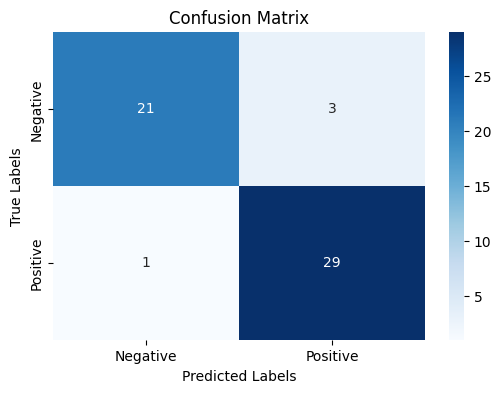

```python
from sklearn.metrics import roc_auc_score, accuracy_score, classification_report, confusion_matrix, recall_score

# Get the best estimator from the GridSearchCV
best_dialysis_model = grid_search_roc_recall_2.best_estimator_

# Make predictions on the test set
y_pred_2 = best_dialysis_model.predict(X_test_2)

# Accuracy
print(f"Test Accuracy: {accuracy_score(y_test_2, y_pred_2)}")

# ROC AUC score
print(f"Test ROC AUC score: {roc_auc_score(y_test_2, y_pred_2)}")

# Recall score
print(f"Test Recall score: {recall_score(y_test_2, y_pred_2)}")

# Classification report
print("Classification Report:")
print(classification_report(y_test_2, y_pred_2))

# Compute the confusion matrix
cm = confusion_matrix(y_test_2, y_pred_2)

# Create a heatmap for the confusion matrix
plt.figure(figsize=(6, 4))
sns.heatmap(cm, annot=True, fmt='g', cmap='Blues', xticklabels=['Negative', 'Positive'], yticklabels=['Negative', 'Positive'])
plt.title("Confusion Matrix")
plt.xlabel("Predicted Labels")
plt.ylabel("True Labels")
plt.show()
```

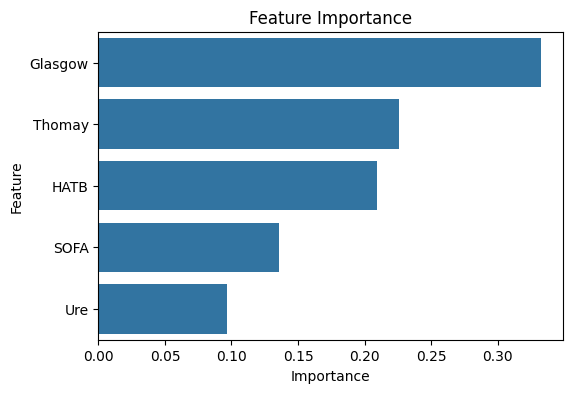

```python
# Get feature importances from the best model
importances_2 = best_dialysis_model.named_steps['classifier'].feature_importances_

# Get the feature names (assuming numerical and categorical features are already combined)
# Use the column names of the dataset (after preprocessing, it would be the original columns)
feature_names_2 = X2.columns.tolist()  # Use the column names from the dataset you're working with

# Create a DataFrame for feature importances
feature_importance_df_2 = pd.DataFrame({
    'Feature': feature_names_2,
    'Importance': importances_2
})

# Sort the features by importance
feature_importance_df_2 = feature_importance_df_2.sort_values(by='Importance', ascending=False)

# Plot the feature importances using Seaborn
plt.figure(figsize=(6, 4))
sns.barplot(x='Importance', y='Feature', data=feature_importance_df_2)
plt.title('Feature Importance')
plt.xlabel('Importance')
plt.ylabel('Feature')
plt.show()
```

##### **Feature Importance / SHAP Interpretation (for predicting Dialysis):**

```
Shape of shap_values_class_2: (215, 5)
Shape of X_train_2: (215, 5)
```

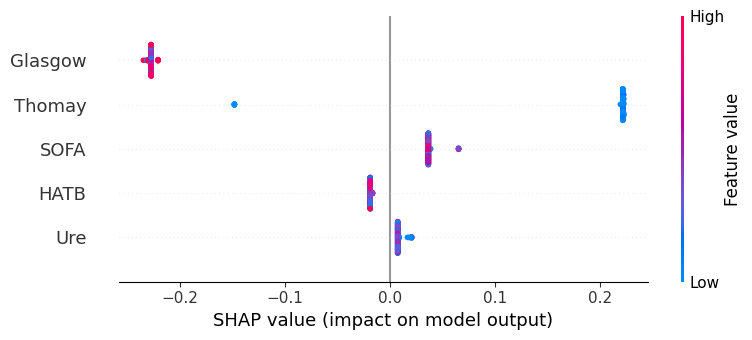

```python
# Initialize SHAP explainer
explainer_2 = shap.TreeExplainer(best_dialysis_model.named_steps['classifier'])

# Get the SHAP values for both classes
shap_values_2 = explainer_2.shap_values(X_train_2)

# Extract SHAP values for class 1 (positive class)
shap_values_class_2 = shap_values_2[:, :, 1]  # Select the SHAP values for class 1

# Print the shapes to check alignment
print(f"Shape of shap_values_class_2: {shap_values_class_2.shape}")
print(f"Shape of X_train_2: {X_train_2.shape}")

# Plot the SHAP summary plot for class 1 (positive class)
shap.summary_plot(shap_values_class_2, X_train_2)
```